# Introduction to Bayesian Statistical Modeling Workshop for Ecologists

2025-10-30

**Instructors**:

Fitsum Abadi Gebreselassie, New Mexico State University, USA (fgebrese@nmsu.edu)

Jason Marshal, Wits University, South Africa (jason.marshal@wits.ac.za)

**Date**: 29–31 October 2025

**Time**: 09h00–16h00

**Venue**: Wits University, Oppenheimer Life Sciences Building, Room 3034A (Nucleus Lab)

**Computer requirements**: Please bring your own laptop with the latest versions of R, RStudio, and JAGS installed

**Registration**: Free

**Application**: Please use the online form to register. The workshop will be limited to 40 participants.

**Workshop Overview**

This three-day hands-on workshop aims to introduce ecologists to statistical modeling using Bayesian approaches and BUGS programming. The workshop will cover

- a brief introduction to R software and to BUGS programming conventions using the language JAGS;
- basic statistical models and their representation in a Bayesian framework, including general linear models, generalized linear models, generalized linear mixed models;
- specialized models in population ecology and wildlife conservation, such as occupancy modelling, population modeling, and integrated population modeling.

**Prerequisites**: Basic knowledge of statistics (i.e. familiarity with simple regression) and some prior exposure to R software. No prior experience with Bayesian statistical modeling is required.

**Required R Packages**

```r
# Load Packages
library(rjags)
library(jagsUI)
library(coda)
library(MCMCvis)
library(ggmcmc)
library(ggplot2)
library(tidyverse)
library(gridExtra)
library(popbio)
```

# 1 Introduction

- Frequentist vs Bayesian approaches (Ellison (1996), Kéry (2010))

| Concept/term | Frequentist | Bayesian |
| --- | --- | --- |
| Probability | Long-run relative frequency of the event in repeated experiments | Degree of belief or uncertainty about an event or parameter |
| Parameter | Fixed but unknown constant | Random with probability distributions |
| Priors | Do not specify priors | Incorporate explicit prior distributions |
| Inference | Based on sampling distributions;Relies on asymptotic theory | Based on full posterior distributions; exact probabilistic inference |
| Error propagation | Not straightforward | Straightforward; handled via the posterior |

- Bayesian inference updates beliefs about parameters using Bayes’ theorem:

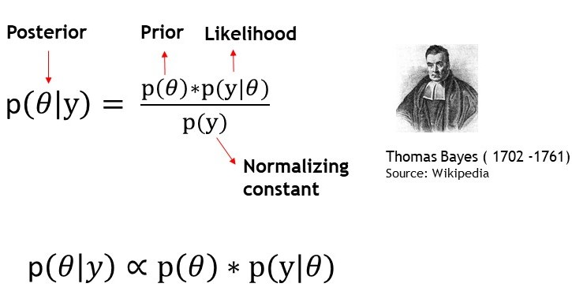

- **Prior:** Initial belief before seeing data
- **Likelihood:** How data relate to parameters
- **Posterior:** Updated belief after data

## 1.1 Uninformative vs informative priors

- **Uninformative:** Minimal prior knowledge
- **Informative:** Incorporates existing knowledge to refine inference

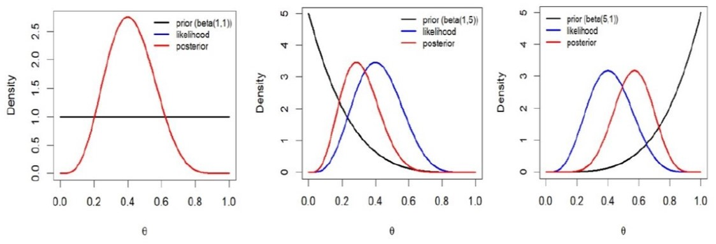

## 1.2 Importance of probability distributions

- They capture uncertainty at all stages—priors, likelihood, and posterior.
- Commonly used probability distributions

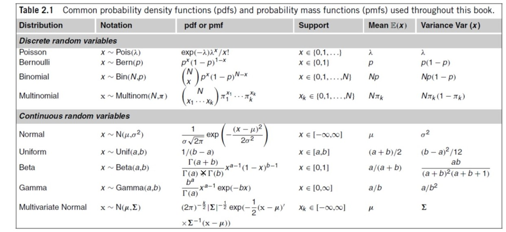

Source: Royle et al. (2014)

## 1.3 Why MCMC?

- Analytical calculation of posteriors is often impossible. MCMC approximates posteriors by sampling from them via Markov chains.
- Components of MCMC
  - **Burn-in:** Initial samples discarded
  - **Iterations:** Number of samples collected
  - **Initial values:** Starting points
  - **Convergence:** Assessed by trace plots, autocorrelation, Gelman-Rubin statistic

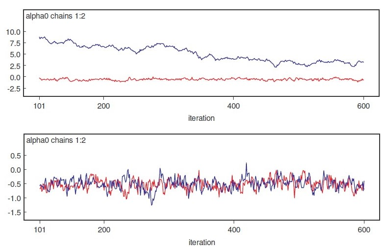

**Software**

- JAGS and BUGS languages are used for Bayesian modeling with MCMC methods.

**Data**

- Simulated datasets and code for this workshop are adapted from Kéry (2010) and Kéry and Schaub (2012).
- Cooper’s hawk dataset is provided with permission from Brian Millsap (NMSU).

[figure not shown]

**Example: Proportion estimation with JAGS**

Suppose we detected a particular species 4 times out of 10 visits at a given site. Estimate the probability that the species is detected on any given visit.

- Bayesian model components:
  - Likelihood:
    $$y \sim \text{Binomial}(n, \theta)$$
    where: $y=4$, $n=10$, and $\theta$ is the unknown detection probability
  - Prior:
    $$\theta \sim \text{Beta}(a, b) \\$$
    A common non-informative prior is:
    $$\theta \sim \text{Beta}(1, 1) \\$$

```r
# Specify the prior and likelihood
M0 <- "
model{
  # Likelihood
  y ~ dbin(theta, n)

  # Priors
  theta ~ dbeta(1, 1)
}#End model
"

# Bundle data
data <- list(y = 4, n = 10)

# Initial values
inits <- function(){list(theta = runif(1, 0, 1))}

# Parameters monitored
params <- c("theta")

#MCMC settings
ni <- 5000
nb <- 2000
nt <- 5
nc <- 3

# Running the model using JagsUI
out_M0 <- jagsUI(data = data, inits = inits, parameters.to.save = params,
        model.file = textConnection(M0), n.chains = nc, n.thin = nt,
        n.iter = ni, n.burnin = nb, verbose = FALSE)

# Print output
print(out_M0, digits = 3)
```

```
## JAGS output for model '5', generated by jagsUI.
## Estimates based on 3 chains of 5000 iterations,
## adaptation = 100 iterations (sufficient),
## burn-in = 2000 iterations and thin rate = 5,
## yielding 1800 total samples from the joint posterior.
## MCMC ran for 0.001 minutes at time 2025-10-30 21:26:33.175397.
##
##           mean    sd  2.5%   50% 97.5% overlap0 f  Rhat n.eff
## theta    0.411 0.136 0.166 0.406 0.693    FALSE 1 1.002   980
## deviance 3.619 1.199 2.767 3.161 7.115    FALSE 1 1.005  1800
##
## Successful convergence based on Rhat values (all < 1.1).
## Rhat is the potential scale reduction factor (at convergence, Rhat=1).
## For each parameter, n.eff is a crude measure of effective sample size.
##
## overlap0 checks if 0 falls in the parameter's 95% credible interval.
## f is the proportion of the posterior with the same sign as the mean;
## i.e., our confidence that the parameter is positive or negative.
##
## DIC info: (pD = var(deviance)/2)
## pD = 0.7 and DIC = 4.338
## DIC is an estimate of expected predictive error (lower is better).
```

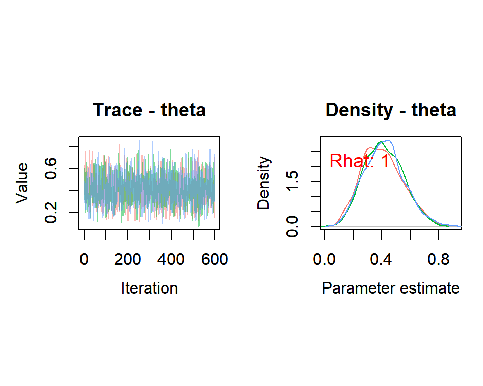

```r
# Convergence diagnostics plots with MCMCvis
# Trace and density plots
samples <- out_M0$samples
MCMCtrace(samples, params = "theta", ind = TRUE, Rhat = TRUE, pdf = FALSE)
```

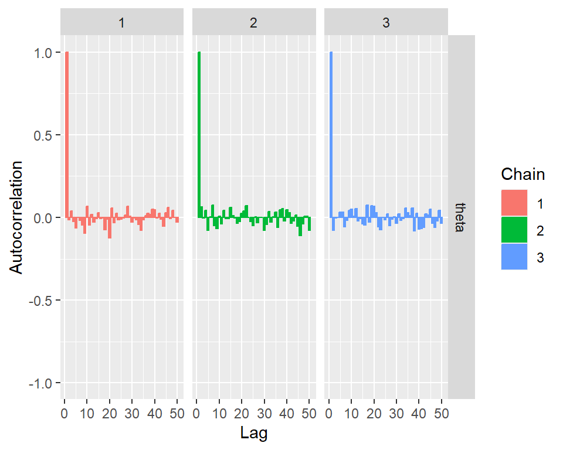

```r
# Use the "ggmcmc" package for autocorrelation plot
out_M0_mcmc <- mcmc.list(out_M0$samples) #convert the output to 'mcmc' list
out_M0_gg <- ggs(out_M0_mcmc) #convert the list to ggmcmc format
ggs_autocorrelation(out_M0_gg, family=c("theta"))
```

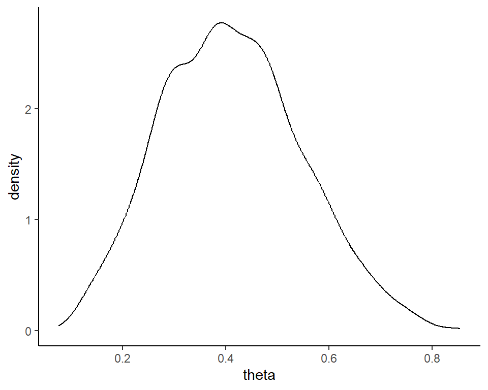

```r
# Posterior density plot for model parameter
ggplot(data=NULL, aes_q(x = out_M0$sims.list$theta)) +
  geom_density() +
  xlab("theta") +
  theme_classic()
```

## 1.4 Exercise

Suppose you have body mass (g) measurements of five passerine birds: 15.2, 14.8, 15.5, 14.9, 15.3. Assuming the body mass follows a normal distribution, estimate the mean body mass using a Bayesian approach.

## 1.5 Reading

Kéry, M. (2010). *Introduction to WinBUGS for Ecologists* (Chapter 2). Academic Press.

# 2 General Linear Models

- General linear models provide a broad framework for modeling relationships between a continuous response (dependent) variable ($Y$) and one or more predictors ($X$).
- Classical hypothesis tests like t-tests, ANOVA, and ANCOVA fit naturally as special cases of general linear models.

## 2.1 Simple Linear Regression

- Models relationship between $Y$ and one continuous predictor $X$:

$$y_i \sim \mathrm{Normal}(\mu_i, \tau)$$

with

$$\mu_i = \alpha_0 + \beta*x_i$$

where: - $\alpha_0$ is the intercept - $\beta$ is the slope - $\tau = 1/\sigma^2$ (precision)

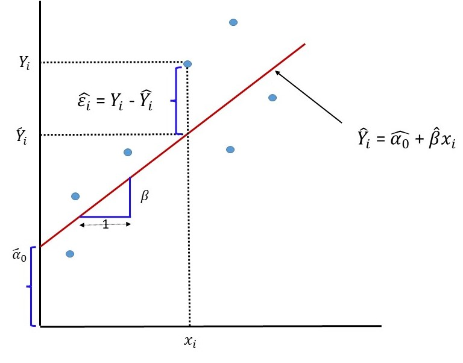

- Bayesian model components:
  - Priors:

$$\alpha_0, \beta \sim \text{Normal}(0, 0.0001), \quad \sigma \sim
\text{Uniform}(0, 100)$$

**Example**

Investigate the relationship between body mass and length of the asp viper. The dataset is provided in “aspviper.csv”.

```r
# Read data
av <- read.csv("aspviper.csv", header = T)
head(av, 5)
```

```
##        mass   length      pop
## 1 127.95606 63.31550 Pyrenees
## 2  90.84274 56.89404 Pyrenees
## 3 101.30909 57.85540 Pyrenees
## 4  81.63790 57.46081 Pyrenees
## 5 161.33287 64.50711 Pyrenees
```

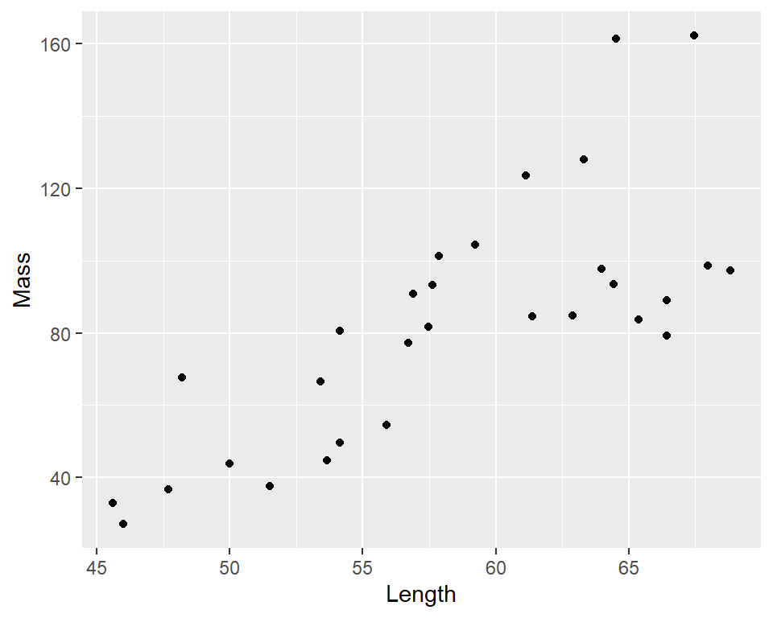

```r
# Scatter plot
ggplot(av, aes(x = length, y = mass)) +
  geom_point() +
  xlab("Length") +
  ylab("Mass")
```

```r
# JAGS code
mod_linear <- "model {
# Priors
 alpha0 ~ dnorm(0, 0.0001)
 beta ~ dnorm(0, 0.0001)
 sigma ~ dunif(0, 100)
 tau <- pow(sigma, -2)

# Likelihood
 for (i in 1:n) {
    y[i] ~ dnorm(mu[i], tau)
    mu[i] <- alpha0 + beta*x[i]
 }
}
"

# Bundle data
y <- av$mass
x <- as.numeric(scale(av$length)) # Standardized

data <- list(y = y, x = x, n = nrow(av))

# Initial values
inits <- function(){list(alpha0 = rnorm(1, 0, 1), beta = rnorm(1, 0, 1),
                         sigma = runif(1, 0, 10))}

# Parameters monitored
params <- c("alpha0", "beta", "sigma")

#MCMC settings
ni <- 5000
nb <- 2000
nt <- 5
nc <- 3

# Running the model using JagsUI
out_linear <- jagsUI(data = data, inits = inits, parameters.to.save = params,
        model.file = textConnection(mod_linear), n.chains = nc, n.thin = nt,
        n.iter = ni, n.burnin = nb, verbose = FALSE)

# Print output
print(out_linear, digits = 3)
```

```
## JAGS output for model '6', generated by jagsUI.
## Estimates based on 3 chains of 5000 iterations,
## adaptation = 100 iterations (sufficient),
## burn-in = 2000 iterations and thin rate = 5,
## yielding 1800 total samples from the joint posterior.
## MCMC ran for 0.007 minutes at time 2025-10-30 21:26:34.614702.
##
##             mean    sd    2.5%     50%   97.5% overlap0 f  Rhat n.eff
## alpha0    82.477 4.300  74.029  82.488  90.843    FALSE 1 1.000  1800
## beta      25.573 4.363  16.783  25.610  34.045    FALSE 1 1.002  1800
## sigma     23.633 3.367  18.097  23.286  30.889    FALSE 1 1.001  1722
## deviance 272.956 2.730 269.928 272.200 280.265    FALSE 1 1.003   782
##
## Successful convergence based on Rhat values (all < 1.1).
## Rhat is the potential scale reduction factor (at convergence, Rhat=1).
## For each parameter, n.eff is a crude measure of effective sample size.
##
## overlap0 checks if 0 falls in the parameter's 95% credible interval.
## f is the proportion of the posterior with the same sign as the mean;
## i.e., our confidence that the parameter is positive or negative.
##
## DIC info: (pD = var(deviance)/2)
## pD = 3.7 and DIC = 276.676
## DIC is an estimate of expected predictive error (lower is better).
```

## 2.2 Two-Sample t-Test

Suppose we want to compare the means of two groups labeled as 1 and 2.

$$y_i \sim \mathrm{Normal}(\mu_i, \tau)$$

$$\mu_i = \alpha_{\text{group}[i]}$$

- $\alpha_1$ is the mean of group 1
- $\alpha_2$ is the mean of group 2
- The classical two-sample t-test hypothesis corresponds to

$$H_0: \alpha_2 - \alpha_1 = 0$$

**Example**

Test whether the mean body mass the asp viper differs between two populations using the dataset “aspviper.csv”.

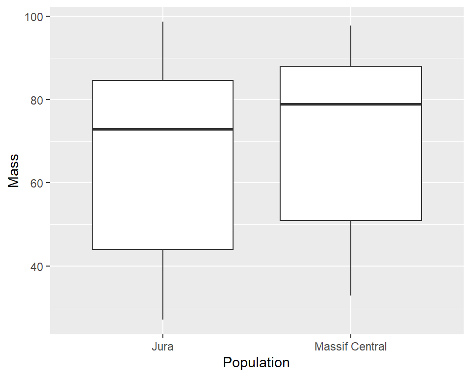

```r
# Data
av1 <- av %>%
  filter(pop == "Jura" | pop == "Massif Central")

ggplot(av1, aes(x = pop, y = mass)) +
  geom_boxplot() +
  xlab("Population") +
  ylab("Mass")
```

```r
# JAGS code - Means parameterization
mod_ttest <- "model {
# Priors
 for(k in 1:2) {
  alpha[k] ~ dnorm(0, 0.0001)  # group-level means
 }
 sigma ~ dunif(0, 100)
 tau <- pow(sigma, -2)

# Likelihood
 for (i in 1:n) {
    y[i] ~ dnorm(mu[i], tau)
    mu[i] <- alpha[g[i]]
 }
# Derived parameter
 delta <- alpha[2] - alpha[1] # difference between groups
}
"

# Bundle data
y <- av1$mass
g <- as.numeric(factor(av1$pop))

data <- list(y = y, g = g, n = nrow(av1))

# Initial values
inits <- function(){list(alpha = rnorm(2, 0, 1),
                         sigma = runif(1, 0, 10))}

# Parameters monitored
params <- c("alpha", "delta", "sigma")

#MCMC settings
ni <- 5000
nb <- 2000
nt <- 5
nc <- 3

# Running the model using JagsUI
out_ttest <- jagsUI(data = data, inits = inits, parameters.to.save = params,
        model.file = textConnection(mod_ttest), n.chains = nc, n.thin = nt,
        n.iter = ni, n.burnin = nb, verbose = FALSE)

# Print output
print(out_ttest, digits = 3)
```

```
## JAGS output for model '7', generated by jagsUI.
## Estimates based on 3 chains of 5000 iterations,
## adaptation = 100 iterations (sufficient),
## burn-in = 2000 iterations and thin rate = 5,
## yielding 1800 total samples from the joint posterior.
## MCMC ran for 0.003 minutes at time 2025-10-30 21:26:35.37399.
##
##             mean     sd    2.5%     50%   97.5% overlap0     f  Rhat n.eff
## alpha[1]  65.728  8.594  48.767  65.889  82.635    FALSE 1.000 1.000  1800
## alpha[2]  69.165  8.663  51.562  69.152  86.493    FALSE 1.000 0.999  1800
## delta      3.437 11.890 -19.601   3.607  26.990     TRUE 0.614 1.000  1800
## sigma     27.115  4.917  19.697  26.387  37.942    FALSE 1.000 1.002  1800
## deviance 186.952  2.731 183.790 186.282 194.070    FALSE 1.000 1.002  1800
##
## Successful convergence based on Rhat values (all < 1.1).
## Rhat is the potential scale reduction factor (at convergence, Rhat=1).
## For each parameter, n.eff is a crude measure of effective sample size.
##
## overlap0 checks if 0 falls in the parameter's 95% credible interval.
## f is the proportion of the posterior with the same sign as the mean;
## i.e., our confidence that the parameter is positive or negative.
##
## DIC info: (pD = var(deviance)/2)
## pD = 3.7 and DIC = 190.683
## DIC is an estimate of expected predictive error (lower is better).
```

```r
##############
# JAGS code - Effects parameterization
mod_ttest1 <- "model {
# Priors
 alpha0 ~ dnorm(0, 0.0001)  # intercept for the first group
 alpha[1] <- 0  # set the first group as a reference category
 for(k in 2:2) {
  alpha[k] ~ dnorm(0, 0.0001)   # group-level intercept deviation
 }
 sigma ~ dunif(0, 100)
 tau <- pow(sigma, -2)

# Likelihood
 for (i in 1:n) {
    y[i] ~ dnorm(mu[i], tau)
    mu[i] <- alpha0 + alpha[g[i]]
 }

# Derived parameter
 mu.pop1 <- alpha0  # mean for the first group
 mu.pop2 <- alpha0 + alpha[2] # mean for the second group
}
"

# Bundle data
y <- av1$mass
g <- as.numeric(factor(av1$pop))

data <- list(y = y, g = g, n = nrow(av1))

# Initial values
inits <- function(){list(alpha0 = rnorm(1, 0, 1), alpha = c(NA, rnorm(1, 0, 1)),
                         sigma = runif(1, 0, 10))}

# Parameters monitored
params <- c("alpha0", "alpha", "mu.pop1", "mu.pop2", "sigma")

#MCMC settings
ni <- 5000
nb <- 2000
nt <- 5
nc <- 3

# Running the model using JagsUI
out_ttest1 <- jagsUI(data = data, inits = inits, parameters.to.save = params,
        model.file = textConnection(mod_ttest1), n.chains = nc, n.thin = nt,
        n.iter = ni, n.burnin = nb, verbose = FALSE)

# Print output
print(out_ttest1, digits = 3)
```

```
## JAGS output for model '8', generated by jagsUI.
## Estimates based on 3 chains of 5000 iterations,
## adaptation = 100 iterations (sufficient),
## burn-in = 2000 iterations and thin rate = 5,
## yielding 1800 total samples from the joint posterior.
## MCMC ran for 0.005 minutes at time 2025-10-30 21:26:35.643477.
##
##             mean     sd    2.5%     50%   97.5% overlap0     f  Rhat n.eff
## alpha0    65.434  8.586  48.758  65.294  82.908    FALSE 1.000 0.999  1800
## alpha[1]   0.000  0.000   0.000   0.000   0.000     TRUE 1.000    NA     1
## alpha[2]   4.329 12.332 -20.930   4.667  28.594     TRUE 0.655 1.000  1800
## mu.pop1   65.434  8.586  48.758  65.294  82.908    FALSE 1.000 0.999  1800
## mu.pop2   69.763  8.902  51.812  69.946  87.208    FALSE 1.000 1.000  1800
## sigma     26.994  4.991  19.452  26.348  38.650    FALSE 1.000 1.000  1800
## deviance 186.941  2.897 183.751 186.190 194.642    FALSE 1.000 0.999  1800
##
## **WARNING** Some Rhat values could not be calculated.
## Successful convergence based on Rhat values (all < 1.1).
## Rhat is the potential scale reduction factor (at convergence, Rhat=1).
## For each parameter, n.eff is a crude measure of effective sample size.
##
## overlap0 checks if 0 falls in the parameter's 95% credible interval.
## f is the proportion of the posterior with the same sign as the mean;
## i.e., our confidence that the parameter is positive or negative.
##
## DIC info: (pD = var(deviance)/2)
## pD = 4.2 and DIC = 191.143
## DIC is an estimate of expected predictive error (lower is better).
```

## 2.3 One-Way ANOVA

Suppose we have 3 groups and want to compare their means.

For 3 groups labeled 1, 2, and 3:

$$y_i \sim \mathrm{Normal}(\mu_i, \tau)$$

$$\mu_i = \alpha_{\text{group}[i]}$$

**Example**

Evaluate whether the mean body mass of the asp viper differs among three populations using the data “aspviper.csv”.

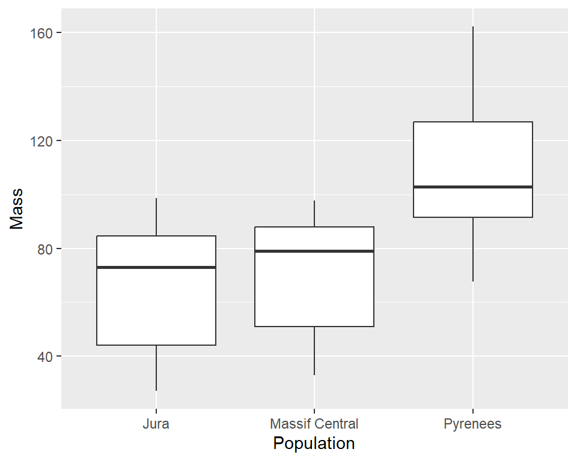

```r
ggplot(av, aes(x = pop, y = mass)) +
  geom_boxplot() +
  xlab("Population") +
  ylab("Mass")
```

```r
# JAGS code
mod_anova <- "model {
# Priors
 for(k in 1:3) {
  alpha[k] ~ dnorm(0, 0.0001)  # group-level means
 }
 sigma ~ dunif(0, 100)
 tau <- pow(sigma, -2)

# Likelihood
 for (i in 1:n) {
    y[i] ~ dnorm(mu[i], tau)
    mu[i] <- alpha[g[i]]
 }

# Derived parameter
 delta.12 <- alpha[2] - alpha[1] # the mean difference between group 2 and group 1
 delta.13 <- alpha[3] - alpha[1]
 delta.23 <- alpha[3] - alpha[2]
}
"

# Bundle data
y <- av$mass
g <- as.numeric(factor(av$pop))

data <- list(y = y, g = g, n = nrow(av))

# Initial values
inits <- function(){list(alpha = rnorm(3, 0, 1),sigma = runif(1, 0, 10))}

# Parameters monitored
params <- c("alpha", "delta.12", "delta.13", "delta.23", "sigma")

#MCMC settings
ni <- 5000
nb <- 2000
nt <- 5
nc <- 3

# Running the model using JagsUI
out_anova <- jagsUI(data = data, inits = inits, parameters.to.save = params,
        model.file = textConnection(mod_anova), n.chains = nc, n.thin = nt,
        n.iter = ni, n.burnin = nb, verbose = FALSE)

# Print output
print(out_anova, digits = 3)
```

```
## JAGS output for model '9', generated by jagsUI.
## Estimates based on 3 chains of 5000 iterations,
## adaptation = 100 iterations (sufficient),
## burn-in = 2000 iterations and thin rate = 5,
## yielding 1800 total samples from the joint posterior.
## MCMC ran for 0.004 minutes at time 2025-10-30 21:26:36.180092.
##
##             mean     sd    2.5%     50%   97.5% overlap0     f  Rhat n.eff
## alpha[1]  65.387  9.209  46.784  65.387  83.442    FALSE 1.000 0.999  1800
## alpha[2]  69.548  9.337  51.221  69.558  87.668    FALSE 1.000 1.000  1800
## alpha[3] 110.228  9.006  92.419 110.234 127.213    FALSE 1.000 1.003  1362
## delta.12   4.161 13.017 -21.737   4.258  28.441     TRUE 0.634 1.000  1800
## delta.13  44.841 13.200  19.580  44.532  71.195    FALSE 1.000 1.001  1800
## delta.23  40.680 12.707  16.284  40.810  66.157    FALSE 0.999 1.000  1800
## sigma     29.124  4.280  22.288  28.724  38.420    FALSE 1.000 1.007   677
## deviance 285.339  3.248 281.468 284.697 293.426    FALSE 1.000 1.009   726
##
## Successful convergence based on Rhat values (all < 1.1).
## Rhat is the potential scale reduction factor (at convergence, Rhat=1).
## For each parameter, n.eff is a crude measure of effective sample size.
##
## overlap0 checks if 0 falls in the parameter's 95% credible interval.
## f is the proportion of the posterior with the same sign as the mean;
## i.e., our confidence that the parameter is positive or negative.
##
## DIC info: (pD = var(deviance)/2)
## pD = 5.3 and DIC = 290.605
## DIC is an estimate of expected predictive error (lower is better).
```

## 2.4 ANCOVA

ANCOVA extends ANOVA and incorporates continuous covariates to adjust group comparisons:

$$y_i \sim \mathrm{Normal}(\mu_i, \tau)$$

$$\mu_i = \alpha_{\text{group}[i]} + \beta*x_i$$

- $\beta$ measures effect of covariate $x_i$
- This model adjusts group means by $x_i$

**Example**

Assess whether the body mass differs among three asp viper populations while controlling for a continuous covariate length. Data are “aspviper.csv”.

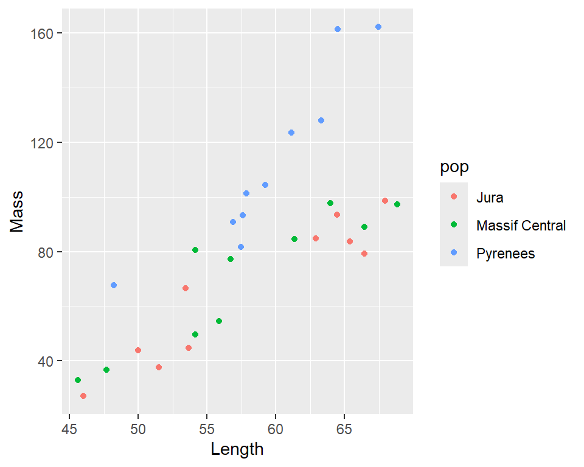

```r
ggplot(av, aes(x = length, y = mass, colour = pop)) +
  geom_point() +
  xlab("Length") +
  ylab("Mass")
```

```r
# JAGS code - Additive ANCOVA model
mod_ancova <- "model {
# Priors
 for(k in 1:3) {
  alpha[k] ~ dnorm(0, 0.0001)
 }

 beta ~ dnorm(0, 0.0001)

 sigma ~ dunif(0, 100)
 tau <- pow(sigma, -2)

# Likelihood
 for (i in 1:n) {
    y[i] ~ dnorm(mu[i], tau)
    mu[i] <- alpha[g[i]] + beta*x[i]
 }
}
"

# Bundle data
y <- av$mass
g <- as.numeric(factor(av$pop))
x <- as.numeric(scale(av$length)) # Standardized

data <- list(y = y, g = g, x = x, n = nrow(av))

# Initial values
inits <- function(){list(alpha = rnorm(3, 0, 1), beta = rnorm(1, 0, 1),
                         sigma = runif(1, 0, 10))}

# Parameters monitored
params <- c("alpha", "beta", "sigma")

#MCMC settings
ni <- 5000
nb <- 2000
nt <- 5
nc <- 3

# Running the model using JagsUI
out_ancova <- jagsUI(data = data, inits = inits, parameters.to.save = params,
        model.file = textConnection(mod_ancova), n.chains = nc, n.thin = nt,
        n.iter = ni, n.burnin = nb, verbose = FALSE)

# Print output
print(out_ancova, digits = 3)
```

```
## JAGS output for model '10', generated by jagsUI.
## Estimates based on 3 chains of 5000 iterations,
## adaptation = 100 iterations (sufficient),
## burn-in = 2000 iterations and thin rate = 5,
## yielding 1800 total samples from the joint posterior.
## MCMC ran for 0.005 minutes at time 2025-10-30 21:26:36.838073.
##
##             mean    sd    2.5%     50%   97.5% overlap0 f  Rhat n.eff
## alpha[1]  66.591 4.244  58.020  66.591  75.058    FALSE 1 1.000  1800
## alpha[2]  72.854 4.423  63.905  72.956  81.402    FALSE 1 1.000  1800
## alpha[3] 107.584 4.513  98.632 107.624 116.192    FALSE 1 1.000  1800
## beta      23.698 2.588  18.667  23.731  28.901    FALSE 1 1.001  1571
## sigma     13.524 2.021  10.344  13.311  18.238    FALSE 1 1.001  1800
## deviance 240.117 3.664 235.221 239.392 249.191    FALSE 1 0.999  1800
##
## Successful convergence based on Rhat values (all < 1.1).
## Rhat is the potential scale reduction factor (at convergence, Rhat=1).
## For each parameter, n.eff is a crude measure of effective sample size.
##
## overlap0 checks if 0 falls in the parameter's 95% credible interval.
## f is the proportion of the posterior with the same sign as the mean;
## i.e., our confidence that the parameter is positive or negative.
##
## DIC info: (pD = var(deviance)/2)
## pD = 6.7 and DIC = 246.838
## DIC is an estimate of expected predictive error (lower is better).
```

```r
###############
# Interactive ANCOVA model
mod_ancova1 <- "model {
# Priors
 for(k in 1:3) {
  alpha[k] ~ dnorm(0, 0.0001)  # group-level intercept deviations
 }

 for(k in 1:3) {
  beta[k] ~ dnorm(0, 0.0001)  # group-level slope deviations
 }

 sigma ~ dunif(0, 100)
 tau <- pow(sigma, -2)

# Likelihood
 for (i in 1:n) {
    y[i] ~ dnorm(mu[i], tau)
    mu[i] <- alpha[g[i]] + beta[g[i]]*x[i]
 }
}
"

# Bundle data
y <- av$mass
g <- as.numeric(factor(av$pop))
x <- as.numeric(scale(av$length)) # Standardized

data <- list(y = y, g = g, x = x, n = nrow(av))

# Initial values
inits <- function(){list(alpha = rnorm(3, 0, 1),  beta = rnorm(3, 0, 1),
                         sigma = runif(1, 0, 10))}

# Parameters monitored
params <- c("alpha", "beta", "sigma")

#MCMC settings
ni <- 5000
nb <- 2000
nt <- 5
nc <- 3

# Running the model using JagsUI
out_ancova1 <- jagsUI(data = data, inits = inits, parameters.to.save = params,
        model.file = textConnection(mod_ancova1), n.chains = nc, n.thin = nt,
        n.iter = ni, n.burnin = nb, verbose = FALSE)

# Print output
print(out_ancova1, digits = 3)
```

```
## JAGS output for model '11', generated by jagsUI.
## Estimates based on 3 chains of 5000 iterations,
## adaptation = 100 iterations (sufficient),
## burn-in = 2000 iterations and thin rate = 5,
## yielding 1800 total samples from the joint posterior.
## MCMC ran for 0.01 minutes at time 2025-10-30 21:26:37.210684.
##
##             mean    sd    2.5%     50%   97.5% overlap0 f  Rhat n.eff
## alpha[1]  66.308 3.623  59.168  66.243  73.783    FALSE 1 0.999  1800
## alpha[2]  72.488 3.816  65.128  72.443  80.275    FALSE 1 1.001  1765
## alpha[3] 105.511 3.736  98.192 105.500 113.141    FALSE 1 1.003   622
## beta[1]   20.856 3.419  14.213  20.885  27.729    FALSE 1 1.001  1800
## beta[2]   20.059 3.553  13.335  19.994  27.330    FALSE 1 1.001  1800
## beta[3]   38.461 5.153  28.009  38.479  48.439    FALSE 1 1.001  1112
## sigma     11.670 1.807   8.813  11.429  15.820    FALSE 1 1.000  1800
## deviance 230.909 4.418 224.547 230.145 241.645    FALSE 1 1.001  1800
##
## Successful convergence based on Rhat values (all < 1.1).
## Rhat is the potential scale reduction factor (at convergence, Rhat=1).
## For each parameter, n.eff is a crude measure of effective sample size.
##
## overlap0 checks if 0 falls in the parameter's 95% credible interval.
## f is the proportion of the posterior with the same sign as the mean;
## i.e., our confidence that the parameter is positive or negative.
##
## DIC info: (pD = var(deviance)/2)
## pD = 9.8 and DIC = 240.673
## DIC is an estimate of expected predictive error (lower is better).
```

## 2.5 Exercise

Fit a model using the data in “coha.csv” to assess how body mass differs between first year (FY) and after first year (AFY) Cooper’s hawks, adjusting for wing length and tarsus length.

## 2.6 Reading

Kéry, M. (2010). *Introduction to WinBUGS for Ecologists* (Chapters 6, 7, 8, 9 & 11). Academic Press.

# 3 Generalized Linear Models (GLMs)

Generalized Linear Models (GLMs) extend general linear models to response variables that may follow different distributions than normal.

Components of a GLM

A GLM consists of three parts:

1. **Random component:** The response variable $y_i$ follows a distribution from the exponential family (e.g., Bernoulli for binary, Poisson for count data).
2. **Systematic component:** A linear predictor with a single covariate

$$\eta_i = \alpha_0 + \beta*x_{i}$$

3. **Link function:** Connects the expected response $\mu_i = E(y_i)$ to the linear predictor:

$$g(\mu_i) = \eta_i \quad \Longleftrightarrow \quad \mu_i = g^{-1}(\eta_i)$$

## 3.1 Logistic Regression

Suppose we have a binary response variable $y_i$:

$$y_i \sim \text{Bernoulli}(p_i), \quad i=1, \ldots, n$$

where $p_i = P(y_i=1)$.

We model $p_i$ using the logit link function:

$$logit(p_i) = \log\left(\frac{p_i}{1 - p_i}\right) = \eta_i$$

A model with a single numeric predictor $x_i$ is:

$$\eta_i = \alpha_0 + \beta*x_i$$

which implies

$$p_i = \frac{\exp(\alpha_0 + \beta*x_i)}{1 + \exp(\alpha_0 + \beta*x_i)}$$

- $\alpha_0$ is the log-odds of success when $x_i=0$
- $\beta$ is the change in log-odds per unit increase in $x_i$

**Example**

Examine how terrain slope influences the detection probability of coyote. The dataset is provided in “coyote.csv”.

```r
# Read data
coyote <- read.csv("coyote.csv", header = T)

#JAGS code
mod_logistic <- "model {
# Priors
 alpha0 ~ dnorm(0, 0.0001)
 beta ~ dnorm(0, 0.0001)

# Likelihood
 for (i in 1:n) {
    y[i] ~ dbern(p[i])
    logit(p[i]) <- alpha0 + beta*x[i]
 }
}
"

# Bundle data
y <- coyote$detection
x <- as.numeric(scale(coyote$slope)) # standardized

data <- list(y = y, x = x, n = length(y))

# Initial values
inits <- function(){list(alpha0 = rnorm(1, 0, 1), beta = rnorm(1, 0, 1))}

# Parameters monitored
params <- c("alpha0", "beta")

#MCMC settings
ni <- 5000
nb <- 2000
nt <- 5
nc <- 3

# Running the model using JagsUI
out_logistic <- jagsUI(data = data, inits = inits, parameters.to.save = params,
                     model.file = textConnection(mod_logistic), n.chains = nc, n.thin = nt,
                     n.iter = ni, n.burnin = nb, verbose = FALSE)

# Print output
print(out_logistic, digits = 3)
```

```
## JAGS output for model '12', generated by jagsUI.
## Estimates based on 3 chains of 5000 iterations,
## adaptation = 100 iterations (sufficient),
## burn-in = 2000 iterations and thin rate = 5,
## yielding 1800 total samples from the joint posterior.
## MCMC ran for 0.01 minutes at time 2025-10-30 21:26:37.978171.
##
##            mean    sd   2.5%    50%  97.5% overlap0     f  Rhat n.eff
## alpha0   -1.069 0.536 -2.184 -1.035 -0.073    FALSE 0.983 1.000  1800
## beta     -1.497 0.665 -3.057 -1.445 -0.409    FALSE 0.996 1.002  1800
## deviance 27.098 2.160 25.040 26.434 33.251    FALSE 1.000 1.003  1800
##
## Successful convergence based on Rhat values (all < 1.1).
## Rhat is the potential scale reduction factor (at convergence, Rhat=1).
## For each parameter, n.eff is a crude measure of effective sample size.
##
## overlap0 checks if 0 falls in the parameter's 95% credible interval.
## f is the proportion of the posterior with the same sign as the mean;
## i.e., our confidence that the parameter is positive or negative.
##
## DIC info: (pD = var(deviance)/2)
## pD = 2.3 and DIC = 29.431
## DIC is an estimate of expected predictive error (lower is better).
```

## 3.2 Poisson Regression

Suppose we have count data $y_i$:

$$y_i \sim \text{Poisson}(\lambda_i), \quad i=1, \ldots, n$$

We model $\lambda_i$ using the log link function:

$$\log(\lambda_i) = \eta_i$$
A model with a single numeric predictor $x_i$ is:

$$\eta_i = \alpha_0 + \beta*x_i$$

which implies

$$\lambda_i = \exp(\alpha_0 + \beta*x_i)$$

- $\alpha_0$ is the log expected count when $x_i=0$
- $\beta$ is the log multiplicative change in expected count per unit increase in $x_i$

**Example**

Examine the association between ectoparasite counts and wing length in dragonflies. The dataset is provided in “dragonfly.csv”.

```r
# Read data
dragonfly <- read.csv("dragonfly.csv", header = T)

#JAGS code
mod_poisson <- "model {
# Priors
 alpha0 ~ dnorm(0, 0.0001)
 beta ~ dnorm(0, 0.0001)

# Likelihood
 for (i in 1:n) {
    y[i] ~ dpois(lambda[i])
    log(lambda[i]) <- alpha0 + beta*x[i]
 }
}
"

# Bundle data
y <- dragonfly$count
x <- as.numeric(scale(dragonfly$length)) # standardized

data <- list(y = y, x = x, n = length(y))

# Initial values
inits <- function(){list(alpha0 = rnorm(1, 0, 1), beta = rnorm(1, 0, 1))}

# Parameters monitored
params <- c("alpha0", "beta")

#MCMC settings
ni <- 5000
nb <- 2000
nt <- 5
nc <- 3

# Running the model using JagsUI
out_poisson <- jagsUI(data = data, inits = inits, parameters.to.save = params,
                     model.file = textConnection(mod_poisson), n.chains = nc, n.thin = nt,
                     n.iter = ni, n.burnin = nb, verbose = FALSE)

# Print output
print(out_poisson, digits = 3)
```

```
## JAGS output for model '13', generated by jagsUI.
## Estimates based on 3 chains of 5000 iterations,
## adaptation = 100 iterations (sufficient),
## burn-in = 2000 iterations and thin rate = 5,
## yielding 1800 total samples from the joint posterior.
## MCMC ran for 0.075 minutes at time 2025-10-30 21:26:38.60575.
##
##             mean    sd    2.5%     50%   97.5% overlap0 f  Rhat n.eff
## alpha0     4.612 0.010   4.592   4.612   4.633    FALSE 1 1.000  1800
## beta       0.319 0.010   0.299   0.319   0.339    FALSE 1 1.000  1800
## deviance 739.549 2.008 737.564 738.911 744.870    FALSE 1 1.001  1800
##
## Successful convergence based on Rhat values (all < 1.1).
## Rhat is the potential scale reduction factor (at convergence, Rhat=1).
## For each parameter, n.eff is a crude measure of effective sample size.
##
## overlap0 checks if 0 falls in the parameter's 95% credible interval.
## f is the proportion of the posterior with the same sign as the mean;
## i.e., our confidence that the parameter is positive or negative.
##
## DIC info: (pD = var(deviance)/2)
## pD = 2 and DIC = 741.568
## DIC is an estimate of expected predictive error (lower is better).
```

## 3.3 Exercises

1. The file “coha1.csv”” contains data on Cooper’s hawk presence (1) and absence (0) from a single visit to 35 nests. Data include prey abundance and a habitat covariate with categories residential or park (1) and industrial (2). Fit an appropriate model to examine the effects of these two covariates on Cooper’s hawk presence.
2. The file “coha2.csv” contains data on Cooper’s hawk brood counts from 25 nests. For each nesting territory, the maximum count observed from three surveys is recorded as the brood size. The data also include the age of the female breeder (FY = 1 year old, and AFY: older than 1 year) and the distance in meters to the nearest adjacent other occupied Cooper’s hawk nest. Fit an appropriate model to evaluate how brood size relates to female breeder age and nearest neighbor distance.

## 3.4 Reading

Kéry, M. (2010). *Introduction to WinBUGS for Ecologists* (Chapters 13, 15 & 18). Academic Press.

# 4 Mixed-effects models

## 4.1 Linear mixed-effects models (LMMs)

Linear mixed-effects models (LMMs) extend general linear models by including random effects to account for dependencies and variations arising from grouped or hierarchical data structures.

**Random intercept model**

$$y_i \sim \mathrm{Normal}(\mu_i, \tau)$$

$$\mu_i = \alpha_{\text{group}[i]} + \beta x_i$$

$$\alpha_j \sim \mathrm{Normal}(\mu_{\alpha}, \tau_{\alpha}), \quad j=1,
\ldots, J$$

- $\alpha_{\text{group}[i]}$ is a random intercept for group $i$, capturing group-level deviations.
- $\beta$ measures the effect of covariate $x_i$.
- $J$ is the total number of levels of the grouping variable.
- $\mu_{\alpha}$ and $\tau_{\alpha}$ are hyperparameters describing the distribution of group intercepts.

**Random intercept and slope model**

$$y_i \sim \mathrm{Normal}(\mu_i, \tau)$$

$$\mu_i = \alpha_{\text{group}[i]} + \beta_{\text{group}[i]} x_i$$

$$\alpha_j \sim \mathrm{Normal}(\mu_{\alpha}, \tau_{\alpha}), \quad
\beta_j \sim \mathrm{Normal}(\mu_{\beta}, \tau_{\beta}), \quad j = 1,
\ldots, J$$

- $\alpha_{\text{group}[i]}$ and $\beta_{\text{group}[i]}$ are random intercept and slope for group $i$.
- $\mu_{\alpha}, \mu_{\beta}, \tau_{\alpha}, \tau_{\beta}$ are hyperparameters describing the population distribution of random effects.

**Example**

```r
# Read data
snake <- read.csv("snake.csv", header = T)

#JAGS code
mod_lmm <- "model {
# Priors
 for(k in 1:K) {
  alpha[k] ~ dnorm(mu.alpha, tau.alpha)  # random intercepts
 }

 mu.alpha ~ dnorm(0, 0.0001) # mean hyperparameter for random intercepts
 sigma.alpha ~ dunif(0, 100) # sd hyperparameter for random intercepts
 tau.alpha <- pow(sigma.alpha, -2)

  beta ~ dnorm(0, 0.0001)

 sigma ~ dunif(0, 100) # Residual sd
 tau <- pow(sigma, -2)

# Likelihood
 for (i in 1:n) {
    y[i] ~ dnorm(mu[i], tau)
    mu[i] <- alpha[g[i]] + beta*x[i]
 }
}
"

# Bundle data
y <- snake$mass
g <- snake$pop
x <- as.numeric(scale(snake$length)) # standardized
K <- length(unique(snake$pop))

data <- list(y = y, g = g, x = x, n = length(y), K = K)

# Initial values
inits <- function(){list(mu.alpha = rnorm(1, 0, 1), beta = rnorm(1, 0, 1),
                         sigma.alpha = runif(1, 0, 10), sigma = runif(1, 0, 10))}

# Parameters monitored
params <- c("mu.alpha", "sigma.alpha", "beta", "sigma", "alpha")

#MCMC settings
ni <- 5000
nb <- 2000
nt <- 5
nc <- 3

# Running the model using JagsUI
out_lmm <- jagsUI(data = data, inits = inits, parameters.to.save = params,
                     model.file = textConnection(mod_lmm), n.chains = nc, n.thin = nt,
                     n.iter = ni, n.burnin = nb, verbose = FALSE)

# Print output
print(out_lmm, digits = 3)
```

```
## JAGS output for model '14', generated by jagsUI.
## Estimates based on 3 chains of 5000 iterations,
## adaptation = 100 iterations (sufficient),
## burn-in = 2000 iterations and thin rate = 5,
## yielding 1800 total samples from the joint posterior.
## MCMC ran for 0.035 minutes at time 2025-10-30 21:26:43.139904.
##
##                 mean     sd     2.5%      50%    97.5% overlap0 f  Rhat n.eff
## mu.alpha     227.239 13.963  195.143  228.404  250.914    FALSE 1 1.002  1800
## sigma.alpha   29.129 13.757   12.900   25.914   68.403    FALSE 1 1.008  1006
## beta          45.654  2.905   39.944   45.683   51.529    FALSE 1 1.000  1800
## sigma         42.659  2.180   38.629   42.565   47.117    FALSE 1 1.000  1800
## alpha[1]     219.555  6.913  205.819  219.389  232.881    FALSE 1 1.000  1800
## alpha[2]     212.367  6.983  197.854  212.624  225.427    FALSE 1 1.000  1800
## alpha[3]     258.126  7.232  243.815  257.897  272.751    FALSE 1 1.000  1800
## alpha[4]     237.440  7.074  223.889  237.508  251.045    FALSE 1 1.000  1800
## alpha[5]     248.786  7.095  234.939  248.850  263.106    FALSE 1 1.000  1800
## alpha[6]     211.306  7.040  197.173  211.340  225.176    FALSE 1 1.003   758
## deviance    2170.876  4.187 2164.688 2170.175 2180.751    FALSE 1 1.001  1800
##
## Successful convergence based on Rhat values (all < 1.1).
## Rhat is the potential scale reduction factor (at convergence, Rhat=1).
## For each parameter, n.eff is a crude measure of effective sample size.
##
## overlap0 checks if 0 falls in the parameter's 95% credible interval.
## f is the proportion of the posterior with the same sign as the mean;
## i.e., our confidence that the parameter is positive or negative.
##
## DIC info: (pD = var(deviance)/2)
## pD = 8.8 and DIC = 2179.647
## DIC is an estimate of expected predictive error (lower is better).
```

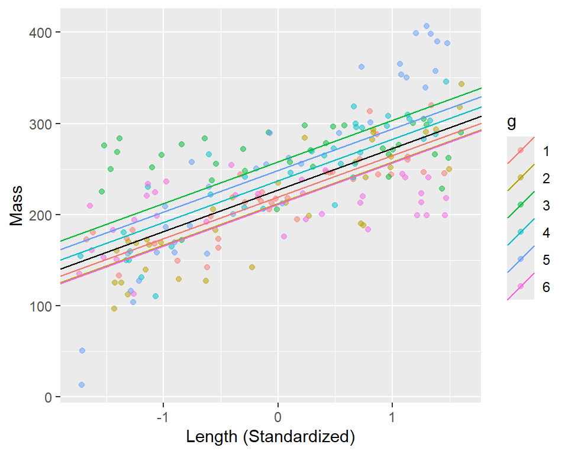

```r
# Plot population-averaged and population-specific regression lines
# Posterior means from JagsUI
mu.alpha <- out_lmm$summary[1,1] # overall intercept
beta <- out_lmm$summary[3,1] # overall slope
alpha <- c(out_lmm$summary[5,1], out_lmm$summary[6,1],
           out_lmm$summary[7,1], out_lmm$summary[8,1],
           out_lmm$summary[9,1],out_lmm$summary[10,1]) # population-specific intercepts

# Create a data frame
df <- data.frame(y = y, x = x, g =factor(g))

# Data frame of group-specific coefficients
coef_df <- data.frame(
  alpha = alpha,
  beta = beta,
  ug = factor(levels(df$g)) # unique levels of the group
)

ggplot(df, aes(x = x, y = y)) +
  geom_point(aes(color = g), alpha = 0.5) +
  geom_abline(intercept = mu.alpha, slope = beta, color = "black") +
  geom_abline(data = coef_df, aes(intercept = alpha, slope = beta, color = ug)) +
  ylab("Mass") +
  xlab("Length (Standardized)")
```

## 4.2 Exercise

The R package “partR2” (Stoffel et al. 2021) includes a dataset on invertebrate biomass and 10 additional variables. For this exercise, use the variables population, precipitation, and year to fit an appropriate model that assesses the relationship between invertebrate biomass and the explanatory variables precipitation and year, while treating population as random effect. The dataset is provided in “biomass.csv”.

## 4.3 Generalized linear mixed-effects models (GLMMs)

Generalized linear mixed-effects models (GLMMs) extend GLMs by including random effects to account for individual- or group-level variability through hierarchical structures.

**Binary response variable**

$$y_i \sim \mathrm{Bernoulli}(p_i)$$

$$\text{logit}(p_i) = \alpha_{\text{group}[i]} + \beta x_i$$

with

$$\alpha_j \sim \mathrm{Normal}(\mu_{\alpha}, \tau_{\alpha}), \quad j=1,
..., J$$

- Here, $p_i$ is the probability of success.
- $\alpha_{\text{group}[i]}$ models the group-specific random intercept.
- $\beta$ is the fixed effect of covariate $x_i$.

**Poisson response variable**

$$y_i \sim \mathrm{Poisson}(\lambda_i)$$

$$\log(\lambda_i) = \alpha_{\text{group}[i]} + \beta x_i$$

with

$$\alpha_j \sim \mathrm{Normal}(\mu_{\alpha}, \tau_{\alpha}), \quad j=1,
..., J$$

- $\lambda_i$ is the expected count for observation $i$.
- $\alpha_{\text{group}[i]}$ is the group-specific random intercept.
- $\beta$ is the fixed effect coefficient for covariate $x_i$.

**Random intercept and slope**

The above models can be extended to include random slopes.

**Example**

Analyze reproductive success of the woodchat shrike in relation to precipitation during the breeding season, accounting for variation across populations. The dataset is provided in “woodchat.csv”

```r
# Read data
woodchat <- read.csv("woodchat.csv", header = T)

#JAGS code
mod_glmm_bin <- "model {
# Priors
 for(k in 1:K) {
  alpha[k] ~ dnorm(mu.alpha, tau.alpha)  # random intercepts
 }

 mu.alpha ~ dnorm(0, 0.0001) # mean hyperparameter for random intercepts
 sigma.alpha ~ dunif(0, 100) # sd hyperparameter for random intercepts
 tau.alpha <- pow(sigma.alpha, -2)

  beta ~ dnorm(0, 0.0001)

 sigma ~ dunif(0, 100) # Residual sd
 tau <- pow(sigma, -2)

# Likelihood
 for (i in 1:n) {
    y[i] ~ dbern(p[i])
    logit(p[i]) <- alpha[g[i]] + beta*x[i]
 }
}
"

# Bundle data
y <- woodchat$success
g <- woodchat$pop
x <- as.numeric(scale(woodchat$prec)) # standardized
K <- length(unique(woodchat$pop))

data <- list(y = y, g = g, x = x, n = length(y), K = K)

# Initial values
inits <- function(){list(mu.alpha = rnorm(1, 0, 1), beta = rnorm(1, 0, 1),
                         sigma.alpha = runif(1, 0, 10), sigma = runif(1, 0, 10))}

# Parameters monitored
params <- c("mu.alpha", "sigma.alpha", "beta", "sigma", "alpha")

#MCMC settings
ni <- 5000
nb <- 2000
nt <- 5
nc <- 3

# Running the model using JagsUI
out_glmm_bin <- jagsUI(data = data, inits = inits, parameters.to.save = params,
                     model.file = textConnection(mod_glmm_bin), n.chains = nc, n.thin = nt,
                     n.iter = ni, n.burnin = nb, verbose = FALSE)

# Print output
print(out_glmm_bin, digits = 3)
```

```
## JAGS output for model '15', generated by jagsUI.
## Estimates based on 3 chains of 5000 iterations,
## adaptation = 100 iterations (sufficient),
## burn-in = 2000 iterations and thin rate = 5,
## yielding 1800 total samples from the joint posterior.
## MCMC ran for 0.048 minutes at time 2025-10-30 21:26:45.665575.
##
##                mean     sd    2.5%     50%   97.5% overlap0     f  Rhat n.eff
## mu.alpha     -0.658  0.783  -2.226  -0.655   0.813     TRUE 0.860 1.004  1800
## sigma.alpha   1.613  0.920   0.613   1.381   4.091    FALSE 1.000 1.010  1800
## beta         -0.489  0.201  -0.897  -0.480  -0.102    FALSE 0.994 1.000  1600
## sigma        50.649 29.543   2.311  51.542  97.915    FALSE 1.000 1.000  1800
## alpha[1]      0.826  0.451  -0.004   0.803   1.740     TRUE 0.974 1.008   309
## alpha[2]     -1.353  0.494  -2.393  -1.340  -0.428    FALSE 0.999 1.000  1800
## alpha[3]     -0.129  0.390  -0.905  -0.137   0.676     TRUE 0.641 0.999  1800
## alpha[4]     -0.751  0.427  -1.635  -0.732   0.035     TRUE 0.967 1.001  1800
## alpha[5]     -0.373  0.406  -1.197  -0.368   0.396     TRUE 0.822 1.003   615
## alpha[6]     -2.286  0.682  -3.844  -2.246  -1.076    FALSE 1.000 1.003   556
## deviance    169.137  3.799 163.784 168.380 178.635    FALSE 1.000 1.000  1800
##
## Successful convergence based on Rhat values (all < 1.1).
## Rhat is the potential scale reduction factor (at convergence, Rhat=1).
## For each parameter, n.eff is a crude measure of effective sample size.
##
## overlap0 checks if 0 falls in the parameter's 95% credible interval.
## f is the proportion of the posterior with the same sign as the mean;
## i.e., our confidence that the parameter is positive or negative.
##
## DIC info: (pD = var(deviance)/2)
## pD = 7.2 and DIC = 176.359
## DIC is an estimate of expected predictive error (lower is better).
```

## 4.4 Exercise

The file “shrike.csv” contains count of red-backed shrike over 25 years in 6 different populations. Examine population trends while accounting for variation among populations random effects.

## 4.5 Reading

Kéry, M. (2010). *Introduction to WinBUGS for Ecologists* (Chapters 12, 16 & 19). Academic Press.

# 5 Occupancy Models

Occupancy models are hierarchical logistic regression models that estimate species occurrence while accounting for **imperfect detection**.

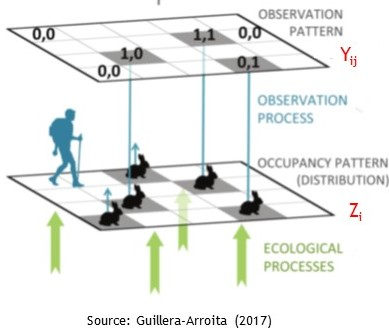

## 5.1 Single-Season Occupancy Models

- Basic sampling design

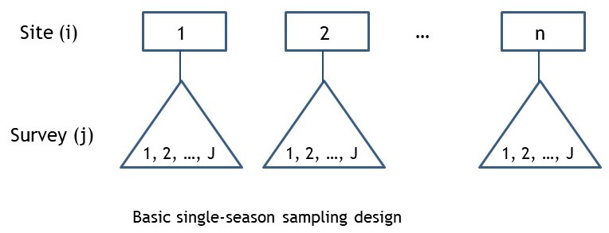

**Key assumption**: The site is **closed** during the survey periods and there are **no false positives**.

**Model description**

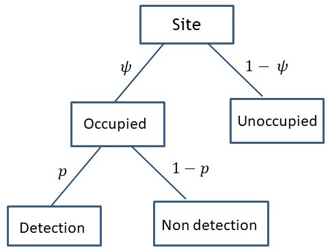

**Ecological (state) process**

$$z_i \sim Bernoulli(\psi_i), \quad logit(\psi_i) = \beta_0 + \beta*x_i$$

**Observation process**

$$y_{ij}|z_i \sim Bernoulli(z_i*p_{ij}), \quad logit(p_{ij}) = \alpha_0 +
\alpha*x_{ij}$$
- Here, $\psi_i$ is the probability of species presence (occupancy probability), and $p_{ij}$ is the probability of detecting the species given presence.

**Example**

Analyze data from three repeated surveys at 100 sites to determine how humidity affects the occurrence of Chiltern gentian. The dataset is provided in “gentian.csv”.

```r
# Read data
gentian <- read.csv("gentian.csv", header = T)

#JAGS code
mod_occ <- "model {
# Priors
 beta0 ~ dunif(-10, 10) #dnorm(0, 1e-6)

 beta ~ dunif(-10, 10) #dnorm(0, 1e-6)

 alpha0 ~ dunif(-10, 10) #dnorm(0, 1e-6)

# Likelihood
   for (i in 1:R){
        #Ecological process
        z[i] ~ dbern(psi[i])
        logit(psi[i]) <- beta0 + beta*x[i]
        for (j in 1:T){
            #Observation process
            y[i,j] ~ dbern(pe[i,j])
            pe[i,j] <- z[i]*p[i,j]  # Can only be detected if z=1
            logit(p[i,j]) <- alpha0
        }
    }
}
"

# Bundle data
y <- gentian[,1:3]
x <- as.numeric(scale(gentian$humidity)) # standardized
R <- nrow(y)
T <- ncol(y)

data <- list(y = y, x = x, R = R, T = T)

# Initial values
zst <- apply(y, 1, max) # initial values for true/latent states
inits <- function(){list(beta0 = rnorm(1, 0, 1), beta = rnorm(1, 0, 1),
                         alpha0 = rnorm(1, 0, 1),
                         z = zst)}

# Parameters monitored
params <- c("beta0", "beta", "alpha0")

#MCMC settings
ni <- 5000
nb <- 2000
nt <- 5
nc <- 3

# Running the model using JagsUI
out_occ <- jagsUI(data = data, inits = inits, parameters.to.save = params,
                     model.file = textConnection(mod_occ), n.chains = nc, n.thin = nt,
                     n.iter = ni, n.burnin = nb, verbose = FALSE)

# Print output
print(out_occ, digits = 3)
```

```
## JAGS output for model '16', generated by jagsUI.
## Estimates based on 3 chains of 5000 iterations,
## adaptation = 100 iterations (sufficient),
## burn-in = 2000 iterations and thin rate = 5,
## yielding 1800 total samples from the joint posterior.
## MCMC ran for 0.11 minutes at time 2025-10-30 21:26:48.630054.
##
##            mean    sd   2.5%    50%  97.5% overlap0     f  Rhat n.eff
## beta0    -1.652 0.290 -2.283 -1.624 -1.137    FALSE 1.000 1.003   811
## beta     -0.200 0.290 -0.770 -0.199  0.365     TRUE 0.749 1.002   814
## alpha0    0.666 0.349 -0.019  0.661  1.356     TRUE 0.973 1.000  1800
## deviance 65.913 6.479 59.627 66.229 82.667    FALSE 1.000 0.999  1800
##
## Successful convergence based on Rhat values (all < 1.1).
## Rhat is the potential scale reduction factor (at convergence, Rhat=1).
## For each parameter, n.eff is a crude measure of effective sample size.
##
## overlap0 checks if 0 falls in the parameter's 95% credible interval.
## f is the proportion of the posterior with the same sign as the mean;
## i.e., our confidence that the parameter is positive or negative.
##
## DIC info: (pD = var(deviance)/2)
## pD = 21 and DIC = 86.922
## DIC is an estimate of expected predictive error (lower is better).
```

## 5.2 Exercise

The file “coha3.csv”” contains data on Cooper’s hawk presence (1) and absence (0) from three visits to 35 nests. The dataset includes prey abundance and a habitat covariate with categories residential or park (1) and industrial (2). Fit an appropriate model to evaluate how Cooper’s hawk presence and detection probabilities relate to prey abundance and habitat type.

## 5.3 Reading

Kéry, M. (2010). *Introduction to WinBUGS for Ecologists* (Chapter 20). Academic Press.

# 6 State-Space Models for Population Counts

State-space models are hierarchical models composed of two sets of equations: 1) the state process, and 2) the observation process.

For population count data: - The **state process equation** describes the true but unknown (latent) population size over time. For a population that grows exponentially, it can be expressed as

$$N_{t+1} = N_t \lambda_t$$
$$\lambda_t \sim \mathrm{Normal}(\mu_\lambda, \tau_\lambda)$$
where $\mu_\lambda$ is the long-term growth rate of the population.

- The **observation process equation** links the observed count data ($y$) with the true population size ($N$).

$$y_t \sim \mathrm{Normal}(N_t, \tau_y)$$

**Example**

Analyze the growth rate of an ibex population monitored over 25 years. The dataset is provided in “ibex.csv”.

```r
# Read data
ibex <- read.csv("ibex.csv", header = T)

#JAGS code
mod_ss <- "model {
# Priors
N.est[1] ~ dunif(2, 10)
mu.lambda ~ dunif(0, 10)
sigma.lambda ~ dunif(0,10) # process sd (environmental stochasticity)
tau.lambda <- pow(sigma.lambda, -2)

sigma.obs ~ dunif(0,10) # observation error sd
tau.obs <- pow(sigma.obs, -2)

# Likelihood
   #State process
   for (t in 1:(T-1)){
        lambda[t] ~ dnorm(mu.lambda, tau.lambda)
        N.est[t+1] <- N.est[t]*lambda[t]
   }
   #Observation process
   for (t in 1:T){
        y[t] ~ dnorm(N.est[t], tau.obs)
    }
}
"

# Bundle data
y <- ibex$count/10  # rescale the data by a factor of 0.1
T <- length(y)

data <- list(y = y, T = T)

# Initial values
inits <- function(){list(mu.lambda = runif(1, 0.1, 2), sigma.lambda = runif(1, 0, 5),
                         sigma.obs = runif(1, 0, 5),
                         N.est = c(runif(1,2,10), rep(NA,(T-1))))}

# Parameters monitored
params <- c("mu.lambda", "sigma.lambda", "sigma.obs", "N.est")

#MCMC settings
ni <- 5000
nb <- 2000
nt <- 5
nc <- 3

# Running the model using JagsUI
out_ss <- jagsUI(data = data, inits = inits, parameters.to.save = params,
                     model.file = textConnection(mod_ss), n.chains = nc, n.thin = nt,
                     n.iter = ni, n.burnin = nb, verbose = FALSE)

# Print output
print(out_ss, digits = 3)
```

```
## JAGS output for model '17', generated by jagsUI.
## Estimates based on 3 chains of 5000 iterations,
## adaptation = 100 iterations (sufficient),
## burn-in = 2000 iterations and thin rate = 5,
## yielding 1800 total samples from the joint posterior.
## MCMC ran for 0.017 minutes at time 2025-10-30 21:26:55.329299.
##
##                mean     sd    2.5%    50%  97.5% overlap0     f  Rhat n.eff
## mu.lambda     1.077  0.039   1.001  1.075  1.157    FALSE 1.000 1.002  1800
## sigma.lambda  0.184  0.040   0.113  0.182  0.269    FALSE 1.000 1.033    75
## sigma.obs     0.305  0.196   0.046  0.274  0.747    FALSE 1.000 1.089    29
## N.est[1]      2.868  0.251   2.266  2.887  3.341    FALSE 1.000 1.041    95
## N.est[2]      2.781  0.251   2.386  2.743  3.357    FALSE 1.000 1.019  1045
## N.est[3]      3.084  0.241   2.684  3.047  3.690    FALSE 1.000 1.028    97
## N.est[4]      3.858  0.253   3.325  3.865  4.417    FALSE 1.000 1.011   555
## N.est[5]      4.360  0.267   3.761  4.380  4.872    FALSE 1.000 1.017   155
## N.est[6]      5.122  0.317   4.398  5.190  5.637    FALSE 1.000 1.010   218
## N.est[7]      4.680  0.306   4.199  4.612  5.437    FALSE 1.000 1.012   173
## N.est[8]      5.852  0.385   4.900  5.952  6.399    FALSE 1.000 1.025    82
## N.est[9]      4.947  0.291   4.469  4.882  5.645    FALSE 1.000 1.043    57
## N.est[10]     5.398  0.274   4.780  5.446  5.892    FALSE 1.000 1.018   276
## N.est[11]     5.439  0.301   4.715  5.474  5.965    FALSE 1.000 1.022   231
## N.est[12]     4.961  0.313   4.247  4.975  5.620    FALSE 1.000 1.029   194
## N.est[13]     4.476  0.292   3.827  4.492  5.098    FALSE 1.000 1.021   142
## N.est[14]     3.849  0.384   3.329  3.774  4.776    FALSE 1.000 1.045    50
## N.est[15]     5.013  0.289   4.408  5.040  5.655    FALSE 1.000 1.053   110
## N.est[16]     5.792  0.326   5.049  5.849  6.364    FALSE 1.000 1.026   522
## N.est[17]     5.957  0.300   5.246  5.982  6.526    FALSE 1.000 1.022   635
## N.est[18]     6.114  0.335   5.315  6.160  6.709    FALSE 1.000 1.022   474
## N.est[19]     5.696  0.299   5.097  5.695  6.380    FALSE 1.000 1.011  1800
## N.est[20]     4.985  0.352   4.480  4.895  5.879    FALSE 1.000 1.013   362
## N.est[21]     6.082  0.286   5.471  6.093  6.672    FALSE 1.000 1.019   434
## N.est[22]     7.130  0.320   6.357  7.163  7.747    FALSE 1.000 1.018   611
## N.est[23]     7.530  0.361   6.994  7.433  8.395    FALSE 1.000 1.018   143
## N.est[24]    10.644  0.356   9.772 10.715 11.258    FALSE 1.000 1.013   345
## N.est[25]    12.250  0.353  11.391 12.280 12.927    FALSE 1.000 1.012  1800
## deviance     -1.579 36.758 -82.844  5.609 53.272     TRUE 0.436 1.252    14
##
## **WARNING** Rhat values indicate convergence failure.
## Rhat is the potential scale reduction factor (at convergence, Rhat=1).
## For each parameter, n.eff is a crude measure of effective sample size.
##
## overlap0 checks if 0 falls in the parameter's 95% credible interval.
## f is the proportion of the posterior with the same sign as the mean;
## i.e., our confidence that the parameter is positive or negative.
##
## DIC info: (pD = var(deviance)/2)
## pD = 574 and DIC = 572.398
## DIC is an estimate of expected predictive error (lower is better).
```

## 6.1 Exercise

The total number of elephants in Kruger Park from 1981 and 1996 is provided in the file “elephant.csv”. Using a state-space modeling approach, estimate the trend and growth rate of the elephant population. Data source: Whyte et al. (2003).

## 6.2 Reading

Kéry, M. and Schaub, M. (2012). *Bayesian Population Analysis Using WinBUGS: A Hierarchical Perspective* (Chapter 5). Academic Press.

# 7 Matrix population models

- Common tools for studying the demography of wildlife populations
- The matrix population model is written as

$${\bf N}_{t+1} = {\bf AN}_{t}$$

where, ${\bf N}_{t}$: a vector containing the number of individuals in each age or stage class at time $t$

${\bf A}$: a projection matrix composed of vital rates (e.g. survival and fecundity rates)

**Example**: Construction of a lifecycle graph and projection matrix

Consider a population with 2 age classes (juvenile and adults ($\geq$ 1 year old)), with the following assumptions:

- The population is censused after breeding
- Age at first breeding is 1 year
- Survival varies by age ($S_0$, $S_1$)
- Fecundity does not vary by age ($F$)

The life cycle of this population is given by

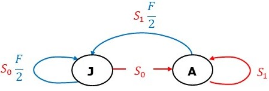

The corresponding female-based matrix population model is

$${\bf N}_{t+1} = {\bf AN}_{t}$$
$$\begin{bmatrix}
N_J \\
N_A
\end{bmatrix}_{t+1}
=
\begin{bmatrix}
S_0\frac{F}{2} & S_1\frac{F}{2} \\
S_0 & S_1
\end{bmatrix}
\begin{bmatrix}
N_J \\
N_A
\end{bmatrix}_t$$
Given the projection matrix **A**, one can compute its eigenvalues and eigenvectors.

- **popbio**: An **R** package for eigenvalues and eigenvectors analysis ({Stubben & Milligan (2007))}
- Biological interpretation of eigenvalues and eigenvectors of **A**:
  - Dominant eigenvalue: **Asymptotic growth rate** ($\lambda$)
  - Right eigenvector (standardized): **Stable age/stage distribution**
  - Left eigenvector (scaled): ** Reproductive value**

**Example**

```r
# Mean demographic estimates.
sj <- 0.24
sa <- 0.47
F <- 3.6

stage <- c("J", "A")

#Projection matrix - note that fecundity is reduced by 1/2 to convert to
#   females produced per female, assuming 50:50 sex ratio at fledging.
A <- matrix(c(sj*F*0.5, sa*F*0.5,
              sj, sa),nrow=2,ncol=2,byrow=T,dimnames=list(stage,stage))
print(A)
```

```
##       J     A
## J 0.432 0.846
## A 0.240 0.470
```

```r
# Asymptotic growth rate - dominant eigenvalue.
lambda(A)
```

```
## [1] 0.902
```

```r
# Stable age/stage distribution - right eigenvector.
stable.stage(A)
```

```
##         J         A
## 0.6428571 0.3571429
```

```r
# Reproductive value - left eigenvector.
reproductive.value(A)
```

```
##        J        A
## 1.000000 1.958333
```

```r
# Sensitivity and elasticity analysis of vital rates. Note, need to rename
#   parameters to avoid overwriting.
tvr <- list(S1 = sj, S2 = sa,
            F = F)

tel <- expression(S1*F*0.5, S2*F*0.5,
                  S1, S2)

options(scipen=999) # turn it off the sci notation

x <- vitalsens(tel, tvr) # function to calculate sensitivity and elasticity
print(x)
```

```
##    estimate sensitivity elasticity
## S1     0.24        1.80  0.4789357
## S2     0.47        1.00  0.5210643
## F      3.60        0.12  0.4789357
```

## 7.1 Exercise: Matrix Population Models

Construct a post-breeding female-based life-cycle graph and a population matrix for the Cooper’s hawk population using the parameter values below, assuming an equal sex ratio.

| Parameter | Value |
| --- | --- |
| Age at first breeding | 1 year |
| Juvenile (J) survival | 0.2 |
| Adult (A) survival | 0.79 |
| J Fecundity | 2.51 |
| A Fecundity | 3.25 |

Using the vital rates provided, determine the long-term population growth rate, stable age distribution and reproductive values for this population. Additionally,perform sensitivity and elasticity analyses to assess the relative influence of each vital rate on lambda. Use the ‘popbio’ package in R to conduct all calculations.

## 7.2 Reading

Morris, W.F. and Doak, D.F. (2002). *Quantitative Conservation Biology. Theory and Practice of Population Viability Analysis* (Chapters 6, 7, 8 & 9). Sinauer, Associates, Inc.